# Landscape Maker

GUI

David Smith, Austin Carter

8/24/2021

```r
library(shiny)
library(shinyFiles)
```

$\uparrow$ Library || Landscapes

## Basic

### Overview

Spatial dynamics are important for mosquito ecology and for malaria transmission. The following GUI accomplishes the following basic tasks:

**Basic Inputs**

- Input the `x,y` coordinates for the spatial elements
- Input the resident human population, $P$
- Input the *Pf*PR
- Assume Ross-Macdonald adult dynamics
- Assume Ross-Macdonald human infection dynamics

**Kernels**

- Set up / adjust the adult mosquito kernel, $\cal K$
- Set up /adjust the time spent matrix, $\Theta$

**Compute**

- From the *Pf*PR, compute $\Lambda$
- Compute the VC matrix, $\cal V$, and the HTCD matrix, $\cal P$
- Compute the next generation matrices

**Visualize**

- Kernels
- Steady States
- Local reproductive numbers
- Connectivity

### Setup

We should coordinate this with Sean so it works as input for `exDE` and `MicroMoB`, but for now:

- Project Directory
- Input Points

#### Project

```r
print(c("Input a project name"))
```

```
## [1] "Input a project name"
```

```r
print(c("Pick a directory where the project will live"))
```

```
## [1] "Pick a directory where the project will live"
```

#### Basics

What mathematical framework?

- Choose **DiffyQ** to set up a spatial model for a mosquito-borne pathogen as a set of coupled ordinary or delay differential equations.
- Choose **Micro-MoB** to set up a discrete time simulation model with Micro-MoB.

```r
MathList = c("DiffyQ", "Micro-MoB")

selectInput("math", "What mathematical framework?", choices = MathList, selected ="DiffyQ")
```

What kind of mosquito model:

```r
pointSetTypes = c("Patches", "Points - BQ", "Points - BQS")

selectInput("pID", "What mathematical framework?", choices = pointSetTypes, selected ="Patches")
```

What disease?

- *SIS* is a generic SIS model
- *SIR* is a generic SIR model
- *Malaria* is a basic malaria model
- *WNV* is a basic West Nile Virus model

```r
DiseaseList = c("SIS", "SIR", "Malaria", "WNV")

selectInput("disease", "What disease?", choices = DiseaseList, selected ="Malaria")
```

```r
nVectorList= c("1", "2", "3")

selectInput("nVectors", "How many mosquito species?", choices = nVectorList, selected ="1")
```

### Locations

```r
howConfigure = c("Defaults", "Input File", "Configure", "Read Model")

selectInput("howConfigure", "How do you want to input the basic configuration?", choices = howConfigure, selected ="Defaults")
```

#### Configure

**How many haunts / patches?**

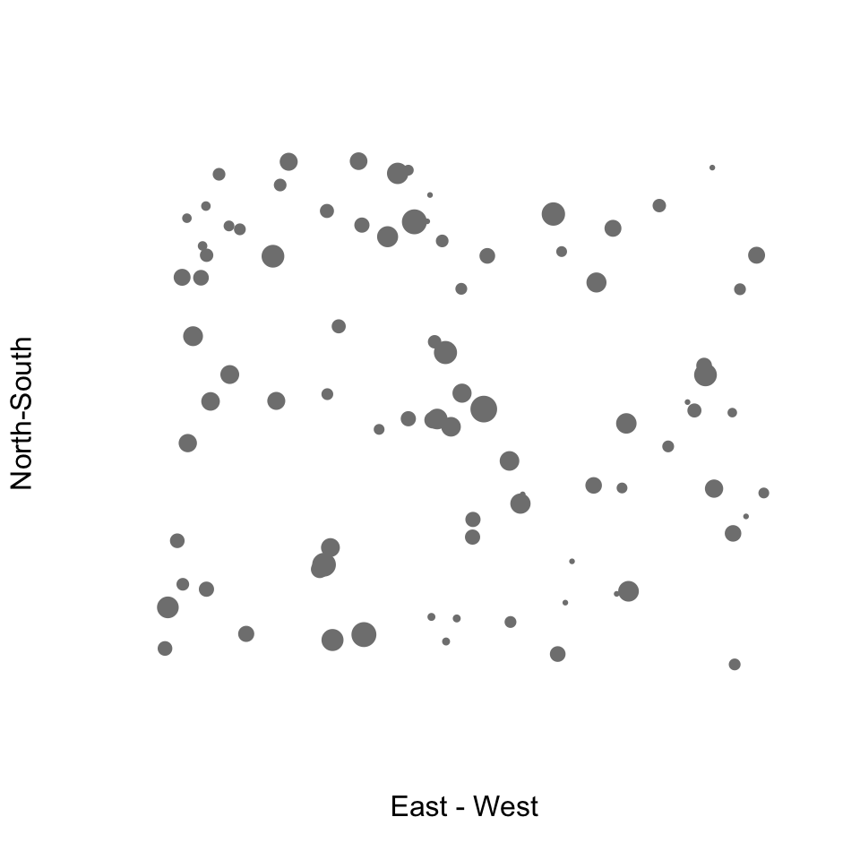

```r
sliderInput("nPatches","nPatches",1, 500, 87)
```

**Resident Population Size**

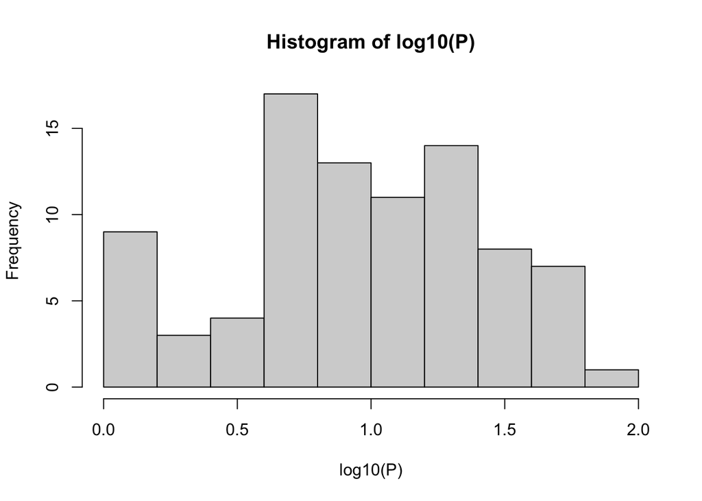

```r
hist(log10(P))
```

#### Kernels

```r
source("../MosquitoDispersal/MosquitoDispersal.R")
```

```r
setup_calK(x,y) -> calK
```

```r
source("../MosquitoDispersal/MosquitoDispersal.R")
```

```r
setup_calK(x,y) -> calK
```

#### `pr2eir` and `pr2M`

## Advanced

- Mirror Indoor / Outdoor
- Add habitat buffer